# C.elegans plate experiment

Anne Bakker

2025-8-7

# **Data inspecteren**

```
## # A tibble: 6 × 34
##   plateRow plateColumn vialNr dropCode expType    expReplicate expName
##   <lgl>    <lgl>        <dbl> <chr>    <chr>             <dbl> <chr>
## 1 NA       NA               1 a        experiment            3 CE.LIQ.FLOW.062
## 2 NA       NA               1 b        experiment            3 CE.LIQ.FLOW.062
## 3 NA       NA               1 c        experiment            3 CE.LIQ.FLOW.062
## 4 NA       NA               1 d        experiment            3 CE.LIQ.FLOW.062
## 5 NA       NA               1 e        experiment            3 CE.LIQ.FLOW.062
## 6 NA       NA               2 a        experiment            3 CE.LIQ.FLOW.062
## # ℹ 27 more variables: expDate <dttm>, expResearcher <chr>, expTime <dbl>,
## #   expUnit <chr>, expVolumeCounted <dbl>, RawData <dbl>, compCASRN <chr>,
## #   compName <chr>, compConcentration <chr>, compUnit <chr>,
## #   compDelivery <chr>, compVehicle <chr>, elegansStrain <chr>,
## #   elegansInput <dbl>, bacterialStrain <chr>, bacterialTreatment <chr>,
## #   bacterialOD600 <dbl>, bacterialConcX <dbl>, bacterialVolume <dbl>,
## #   bacterialVolUnit <chr>, incubationVial <chr>, incubationVolume <dbl>, …
```

# **Scatter plot voor de verschillende chemicaliën en concentraties**

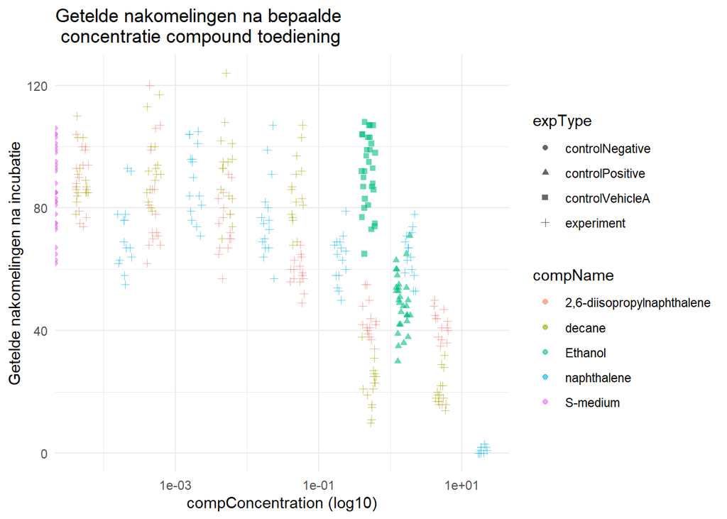

# **Normaliseren van de data voor de negatieve controle**

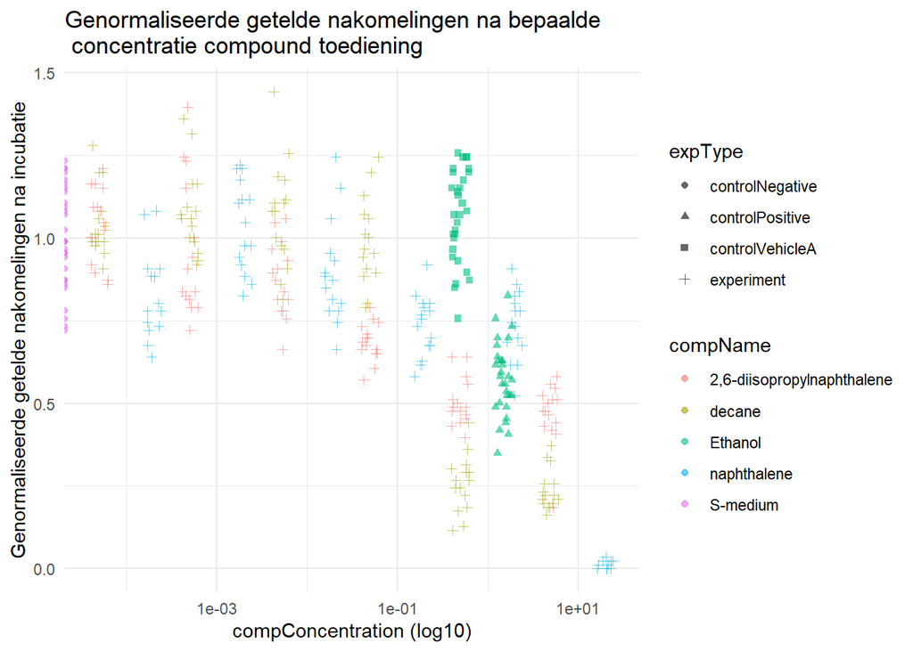

# **Analyse**

In dit experiment is de negatieve controle S-medium. De positieve controle voor dit experiment is ethanol.

Een positieve controle is belangrijk om mee te nemen in het experiment omdat het laat zien of het experiment echt werkt. Er wordt een bekend werkend middel toegediend. Als de positieve controle dan niet aanslaat is er iets fout met het experiment zelf.

Een negatieve controle is belangrijk om mee te nemen in het experiment om te laten zien dat het effect dat waargenomen wordt ontstaat door de stof die wordt toegediend en niet door het experiment of omgeving zelf. De negatieve controle laat het ‘normale’ effect zien zonder interventie. Als je de data normaliseerd met de negatieve waarde heb je het ‘echte’ effect zonder impact van bijvoorbeeld de omgeving of het experiment.

Een vehicle controle is een controle waarbij alleen het oplosmiddel waarin de chemicaliën normaal zit wordt toegediend. Dit wordt gedaan om uit te sluiten dat het oplosmiddel zelf het effect veroorzaakt.

Zoals eerder al besproken bij het belang van de negatieve controle is het normaliseren van de data van nut omdat je dan het effect van alleen de chemicaliën hebt. Ook wordt de interpretatie van de data makkelijker. Een waarde boven de 1 is namelijk een toename en een waarde onder de 1 is een afname.

# **Analyse plan**

**Stap 1: Data-inspectie**

- Begin met het laden van het dataset en inspecteer de structuur ervan.
- Controleer op ontbrekende waarden, uitschieters of andere kwaliteitsproblemen in de data.

**Stap 2: Laad het `drc`-pakket in R**

- Installeer en laad het `drc`-pakket, dat modellen voor dose-response analyse bevat

**Stap 3: Pas en log-logistisch model toe**

- Gebruik het `drm()`-commando om een dose-response model te vinden die past op de data
- Kies het vierparameter log-logistisch model (`LL.4()`). Die wordt het vaakst gebruikt bij dose-response modelling. De vierparameters zijn: helling van de dose-response curve, minimumrespons en maximumrespons en de IC50- waarde (hoeveel van een stof nodig is om een biologisch proces met 50% te remmen)

**Stap 4: Visualiseer dose-respons curve**

- Maak een grafiek waarin zowel de ruwe data als het model worden weergegeven
- De curve laat zien hoe de respons verandert bij toenemende concentratie van de stof.

**Stap 5: Bepaal de IC50-waarde**

- Gebruik de `ED()`-functie om de IC50-waarde te berekenen
- Voor de Effective Dose (`ED()`) bij 50% doe je de code `ED(model, 50)`

Dit geeft de dosis waarbij 50% effect wordt bereikt (IC50), op basis van het model. Het is dus op basis van het geschatte model en niet direct op de ruwe data.